# 🤖 Binary Classification of Machine Failures in R

2023-06-21

# 1 Introduction

“The dataset for this competition (both train and test) was generated from a deep learning model trained on the Machine Failure Predictions. Feature distributions are close to, but not exactly the same, as the original. Feel free to use the original dataset as part of this competition, both to explore differences as well as to see whether incorporating the original in training improves model performance.”

# 2 Importing packages and data

First we are going to open the necessary libraries and the data.

```r
#data
library(stargazer)
library(tidyverse)
library(ggplot2)
library(RColorBrewer)
library(GGally)

##organizing data
library(caret)
library(stargazer)
library(tidyverse)
library(caTools)

##modeling
library(performance)
library(rpart)
library(rpart.plot)
library(rattle)
```

As we can see, there are no NA’s, so we won’t need to imput any values

```r
train <- read.csv("C:/Users/guima/Documents/R/Binary Classification of Machine Failures/train.csv")
test <- read.csv("C:/Users/guima/Documents/R/Binary Classification of Machine Failures/test.csv")

train$Type <- factor(train$Type, levels = c("H", "L", "M"))

summary(train)
```

```
##        id          Product.ID        Type      Air.temperature..K.
##  Min.   :     0   Length:136429      H: 8923   Min.   :295.3
##  1st Qu.: 34107   Class :character   L:95354   1st Qu.:298.3
##  Median : 68214   Mode  :character   M:32152   Median :300.0
##  Mean   : 68214                                Mean   :299.9
##  3rd Qu.:102321                                3rd Qu.:301.2
##  Max.   :136428                                Max.   :304.4
##  Process.temperature..K. Rotational.speed..rpm.  Torque..Nm.    Tool.wear..min.
##  Min.   :305.8           Min.   :1181           Min.   : 3.80   Min.   :  0.0
##  1st Qu.:308.7           1st Qu.:1432           1st Qu.:34.60   1st Qu.: 48.0
##  Median :310.0           Median :1493           Median :40.40   Median :106.0
##  Mean   :309.9           Mean   :1520           Mean   :40.35   Mean   :104.4
##  3rd Qu.:310.9           3rd Qu.:1580           3rd Qu.:46.10   3rd Qu.:159.0
##  Max.   :313.8           Max.   :2886           Max.   :76.60   Max.   :253.0
##  Machine.failure        TWF                HDF               PWF
##  Min.   :0.00000   Min.   :0.000000   Min.   :0.00000   Min.   :0.000000
##  1st Qu.:0.00000   1st Qu.:0.000000   1st Qu.:0.00000   1st Qu.:0.000000
##  Median :0.00000   Median :0.000000   Median :0.00000   Median :0.000000
##  Mean   :0.01574   Mean   :0.001554   Mean   :0.00516   Mean   :0.002397
##  3rd Qu.:0.00000   3rd Qu.:0.000000   3rd Qu.:0.00000   3rd Qu.:0.000000
##  Max.   :1.00000   Max.   :1.000000   Max.   :1.00000   Max.   :1.000000
##       OSF                RNF
##  Min.   :0.000000   Min.   :0.000000
##  1st Qu.:0.000000   1st Qu.:0.000000
##  Median :0.000000   Median :0.000000
##  Mean   :0.003958   Mean   :0.002258
##  3rd Qu.:0.000000   3rd Qu.:0.000000
##  Max.   :1.000000   Max.   :1.000000
```

# 3 Overview

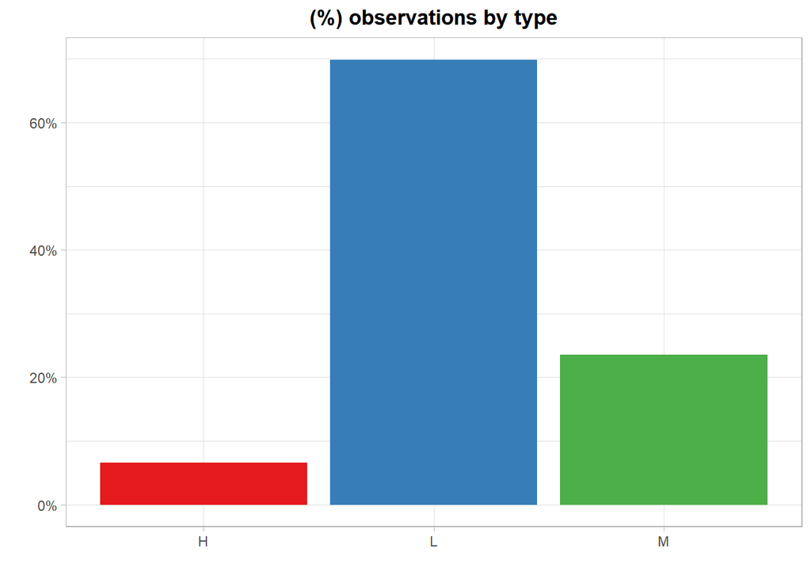

```r
train %>%
  group_by(Type) %>%
  summarise(count = n()) %>%
  mutate(frequency = count*100/sum(count)) %>%
  ggplot(aes(fill=Type, y=frequency, x=Type)) +
  geom_bar(position="dodge", stat="identity") +
  scale_fill_brewer(palette = "Set1") +
  scale_y_continuous(labels = scales::percent_format(scale = 1)) +
  theme_light() +
  labs(title="(%) observations by type",
       fill="",
       x="",
       y="") +
  theme(plot.title = element_text(hjust = 0.5, face = "bold")) +
  theme(legend.position="none")
```

## 3.1 What makes a machine fail?

Machine type seemly does not play an important factor. Between the categorical variables, **HDF, PWF and OSF** seem to be key factors.

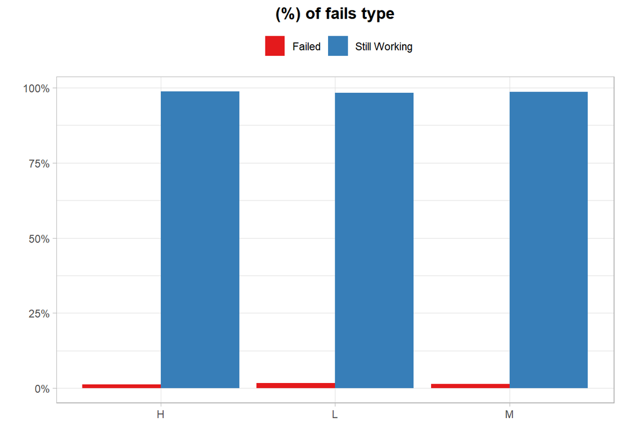

```r
train %>%
  mutate(Fail = ifelse(Machine.failure == 1, "Failed", "Still Working")) %>%
  group_by(Type, Fail) %>%
  summarise(Observations = n()) %>%
  mutate(`Frequency (%)` = Observations*100/sum(Observations)) %>%
  ggplot(aes(fill=Fail, y=`Frequency (%)`, x=Type)) +
  geom_bar(position="dodge", stat="identity") +
  scale_fill_brewer(palette = "Set1") +
  scale_y_continuous(labels = scales::percent_format(scale = 1)) +
  theme_light() +
  labs(title="(%) of fails type",
       fill="",
       x="",
       y="") +
  theme(plot.title = element_text(hjust = 0.5, face = "bold")) +
  theme(legend.position="top")
```

**Rotational Speed, Torque and Tool Wear** also look important.

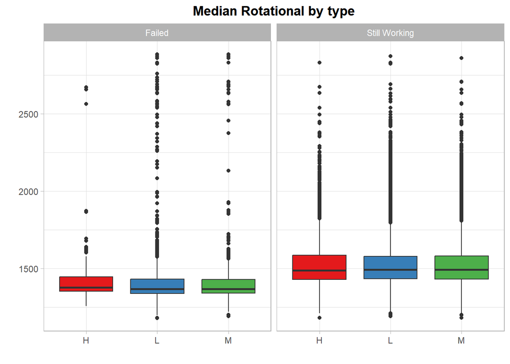

```r
train %>%
  mutate(Fail = ifelse(Machine.failure == 1, "Failed", "Still Working")) %>%
  ggplot(aes(fill=Type, y=Rotational.speed..rpm., x=Type)) +
  geom_boxplot() +
  scale_fill_brewer(palette = "Set1") +
  theme_light() +
  facet_wrap(~Fail) +
  labs(title="Median Rotational by type",
       fill="",
       x="",
       y="") +
  theme(plot.title = element_text(hjust = 0.5, face = "bold")) +
  theme(legend.position="none")
```

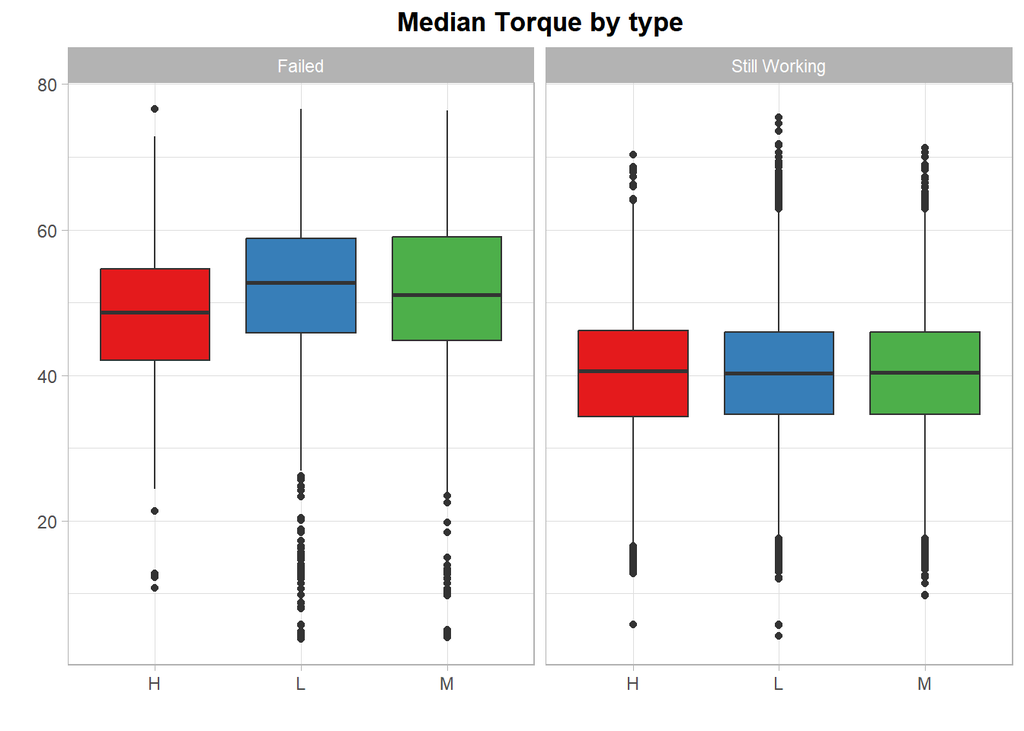

```r
train %>%
  mutate(Fail = ifelse(Machine.failure == 1, "Failed", "Still Working")) %>%
  ggplot(aes(fill=Type, y=Torque..Nm., x=Type)) +
  geom_boxplot() +
  scale_fill_brewer(palette = "Set1") +
  theme_light() +
  facet_wrap(~Fail) +
  labs(title="Median Torque by type",
       fill="",
       x="",
       y="") +
  theme(plot.title = element_text(hjust = 0.5, face = "bold")) +
  theme(legend.position="none")
```

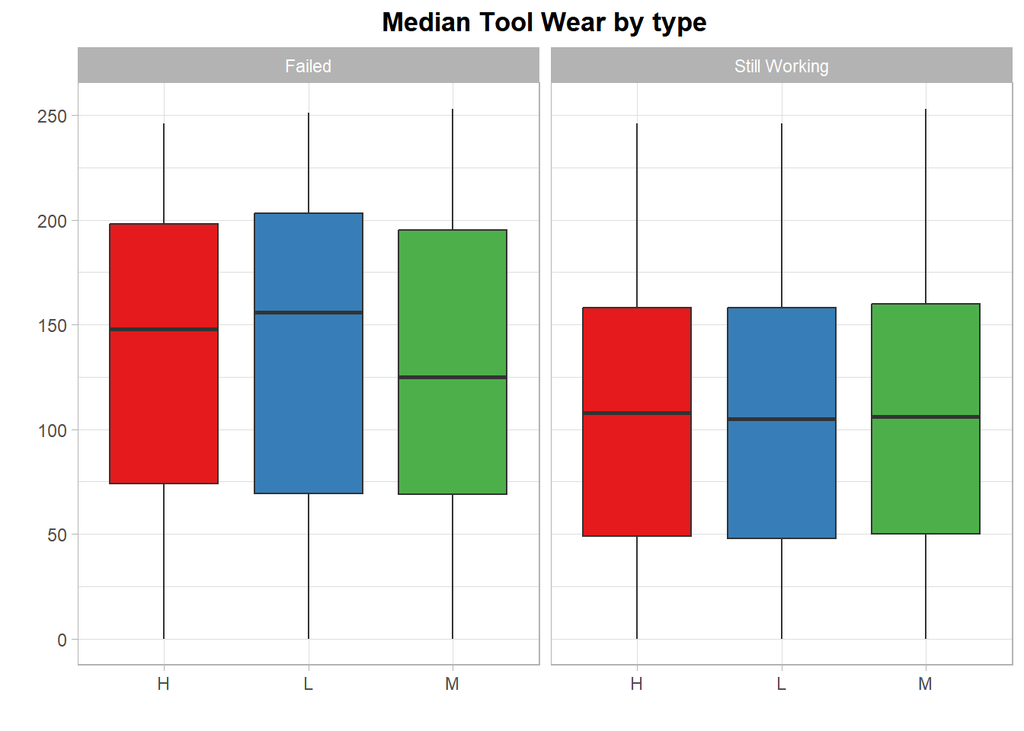

```r
train %>%
  mutate(Fail = ifelse(Machine.failure == 1, "Failed", "Still Working")) %>%
  ggplot(aes(fill=Type, y=Tool.wear..min., x=Type)) +
  geom_boxplot() +
  scale_fill_brewer(palette = "Set1") +
  theme_light() +
  facet_wrap(~Fail) +
  labs(title="Median Tool Wear by type",
       fill="",
       x="",
       y="") +
  theme(plot.title = element_text(hjust = 0.5, face = "bold")) +
  theme(legend.position="none")
```

Another way to view the relationship between machine failure and the variables is through a **correlogram**. In our case, the **Machine.Failure** columns and rows are the most important.

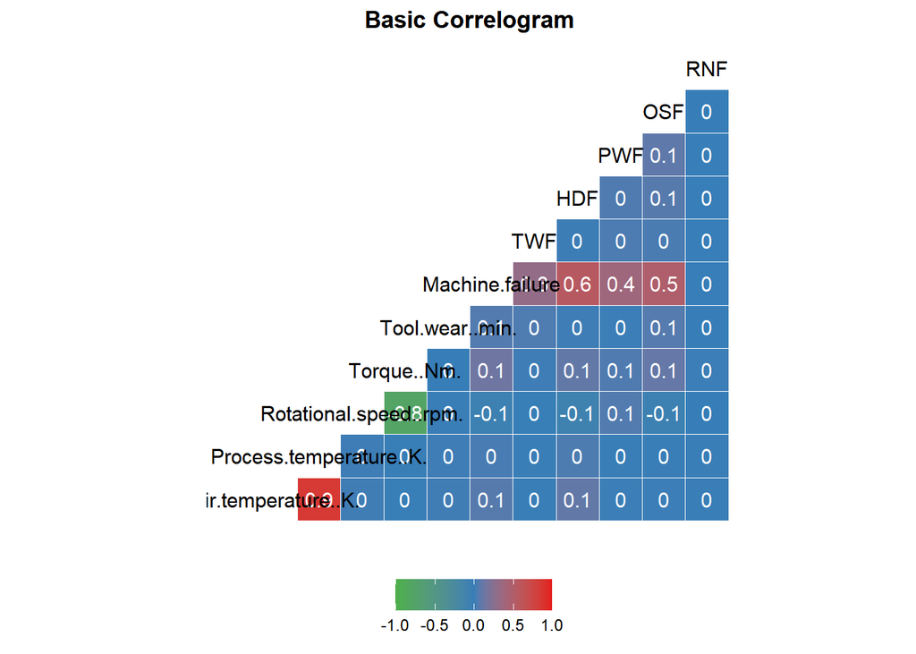

```r
train %>%
  select(!id) %>%
  select(!Product.ID) %>%
  ggcorr(method = c("everything", "pearson"), low = "#4DAF4A" , mid = "#377EB8" , high = "#E41A1C",
         label = TRUE, label_size = 4, label_color = "white",size =4, layout.exp =1) +
  labs(title="Basic Correlogram",
       x="",
       y="") +
  theme(plot.title = element_text(hjust = 0.5, face = "bold")) +
  theme(legend.position="bottom")
```

As we can see, with the exception of RNF, all the categorical variables have a positive correlation with machine failure. Rotational Speed, Torque and Tool Wear also hold a relation with failure - all of this **matches the assumptions we made** through our graphical annalysis.

# 4 Predicting machine failure

We are going to use **3 different prediction models** - most of them are based off the book **Machine Learning with R**, by Brett Lantz. Before actually heading to the models, the first step is **dividing the train dataset into testing and training samples**.

```r
#first, set seed and train our model
df <- train %>%
  select(!id) %>%
  select(!Product.ID)

set.seed(237)

train_index = createDataPartition(y = df$Machine.failure,  # y = our dependent variable.
                                  p = .7,  # Specifies split into 70% & 30%.
                                  list = FALSE,  # Sets results to matrix form.
                                  times = 1)  # Sets number of partitions to create to 1.


#Now we can split our data into train and test data using the randomly sampled train_index that we just formed.

train_data = df[train_index,]  # Use train_index of iris data to create train_data.
test_data = df[-train_index,]  # Use whatever that is not in train_index to create test_data.
```

## 4.1 Logistic regression

📌 What is logistic regression? According to IBM, this type of statistical model (also known as logit model) is often used for classification and predictive analytics. Logistic regression estimates the probability of an event occurring, such as voted or didn’t vote, based on a given dataset of independent variables. We are going to use this model to calculate the **probability of machine failure**.

```r
model_log = glm(Machine.failure~.,
            data = train_data,
            family = "binomial", maxit = 100)
res <- predict(model_log, test_data, type = 'response')
res <- predict(model_log, train_data, type = 'response')

summary(model_log)
```

```
##
## Call:
## glm(formula = Machine.failure ~ ., family = "binomial", data = train_data,
##     maxit = 100)
##
## Coefficients:
##                           Estimate Std. Error z value Pr(>|z|)
## (Intercept)             -2.696e+01  1.258e+01  -2.143   0.0322 *
## TypeL                   -1.078e-01  2.003e-01  -0.538   0.5905
## TypeM                   -5.867e-01  2.319e-01  -2.530   0.0114 *
## Air.temperature..K.      3.530e-01  5.745e-02   6.144 8.04e-10 ***
## Process.temperature..K. -3.087e-01  7.768e-02  -3.974 7.05e-05 ***
## Rotational.speed..rpm.   3.550e-03  3.714e-04   9.559  < 2e-16 ***
## Torque..Nm.              1.278e-01  6.931e-03  18.445  < 2e-16 ***
## Tool.wear..min.          4.171e-03  8.536e-04   4.886 1.03e-06 ***
## TWF                      2.324e+01  2.705e+02   0.086   0.9315
## HDF                      9.231e+00  4.647e-01  19.863  < 2e-16 ***
## PWF                      1.101e+01  7.245e-01  15.194  < 2e-16 ***
## OSF                      9.360e+00  5.893e-01  15.883  < 2e-16 ***
## RNF                      1.049e-01  9.786e-01   0.107   0.9147
## ---
## Signif. codes:  0 '***' 0.001 '**' 0.01 '*' 0.05 '.' 0.1 ' ' 1
##
## (Dispersion parameter for binomial family taken to be 1)
##
##     Null deviance: 15113.5  on 95500  degrees of freedom
## Residual deviance:  4318.3  on 95488  degrees of freedom
## AIC: 4344.3
##
## Number of Fisher Scoring iterations: 16
```

It is woth mentioning that the (***) next to the Pr(>|z|) column is associated with the p-value and represents the** statistical significance** of the variable; if there are no (*), it imples that the variable has no relevance in explaining the results of our model.

📌 The **p value** is defined as the probability of observing the given value of the test statistic, or greater, under the null hypothesis.

Having trained our model, we can plot a **confusion matrix**. This matrix allows us to check how well our regression is doing.

```r
confmatrix <- table(Actual_Value = train_data$Machine.failure, predicted_value = res > 0.5)
confmatrix
```

```
##             predicted_value
## Actual_Value FALSE  TRUE
##            0 94028    12
##            1   345  1116
```

```r
(confmatrix[[1,1]] + confmatrix[[2,2]])*100 / sum(confmatrix)
```

```
## [1] 99.62618
```

As we can see, our regression got **99% of the predictions right** - it is a pretty good result. Now, we can predict the results in our test sample!

```r
pred_log <- predict(model_log, test, type="response")

## Look at probability output
solution_log = data.frame(id = test$id, Machine.failure = ifelse(pred_log > 0.5, 1, 0))
head(solution_log, 5)
```

```
##       id Machine.failure
## 1 136429               0
## 2 136430               0
## 3 136431               0
## 4 136432               0
## 5 136433               0
```

## 4.2 Regression tree

📌 According to Lantz, **trees for numeric prediction** fall into two categories. The first, known as **regression trees**, were introduced in the 1980s as part of the seminal Classification and Regression Tree (CART) algorithm. Despite the name, regression trees do not use linear regression methods as described earlier in this chapter; rather, they make **predictions based on the average value of examples** that reach a leaf.

```r
##training a model on the data
rt_model <- rpart(Machine.failure~., data = train_data)

rt_predict <- predict(rt_model, test_data)

summary(rt_model)
```

```
## Call:
## rpart(formula = Machine.failure ~ ., data = train_data)
##   n= 95501
##
##           CP nsplit rel error    xerror       xstd
## 1 0.32511483      0 1.0000000 1.0000283 0.02555870
## 2 0.22272455      1 0.6748852 0.6749120 0.02121478
## 3 0.11609330      2 0.4521606 0.4522066 0.01748658
## 4 0.08888967      3 0.3360673 0.3361253 0.01512887
## 5 0.01000000      4 0.2471776 0.2472366 0.01300925
##
## Variable importance
##                    HDF                    OSF                    PWF
##                     42                     29                     15
##                    TWF            Torque..Nm. Rotational.speed..rpm.
##                     11                      2                      1
##
## Node number 1: 95501 observations,    complexity param=0.3251148
##   mean=0.01529827, MSE=0.01506423
##   left son=2 (95011 obs) right son=3 (490 obs)
##   Primary splits:
##       HDF         < 0.5    to the left,  improve=0.32511480, (0 missing)
##       OSF         < 0.5    to the left,  improve=0.23877120, (0 missing)
##       PWF         < 0.5    to the left,  improve=0.14047140, (0 missing)
##       TWF         < 0.5    to the left,  improve=0.09720135, (0 missing)
##       Torque..Nm. < 65     to the left,  improve=0.06393301, (0 missing)
##
## Node number 2: 95011 observations,    complexity param=0.2227246
##   mean=0.01027249, MSE=0.01016697
##   left son=4 (94679 obs) right son=5 (332 obs)
##   Primary splits:
##       OSF                    < 0.5    to the left,  improve=0.33170920, (0 missing)
##       PWF                    < 0.5    to the left,  improve=0.19203710, (0 missing)
##       TWF                    < 0.5    to the left,  improve=0.14217860, (0 missing)
##       Torque..Nm.            < 65     to the left,  improve=0.06810915, (0 missing)
##       Rotational.speed..rpm. < 2538.5 to the left,  improve=0.03514948, (0 missing)
##
## Node number 3: 490 observations
##   mean=0.9897959, MSE=0.01009996
##
```

[output cut: 19 more lines]

```
##   Primary splits:
##       TWF                    < 0.5    to the left,  improve=0.2705833000, (0 missing)
##       Torque..Nm.            < 67.25  to the left,  improve=0.0184968500, (0 missing)
##       Rotational.speed..rpm. < 2471.5 to the left,  improve=0.0096066670, (0 missing)
##       Tool.wear..min.        < 202.5  to the left,  improve=0.0081226290, (0 missing)
##       Air.temperature..K.    < 301.85 to the left,  improve=0.0006295212, (0 missing)
##
## Node number 9: 175 observations
##   mean=0.9828571, MSE=0.01684898
##
## Node number 16: 94375 observations
##   mean=0.003666225, MSE=0.003652784
##
## Node number 17: 129 observations
##   mean=1, MSE=0
```

A really nice feature of this method is that it allows us to get a visual representation of the model.

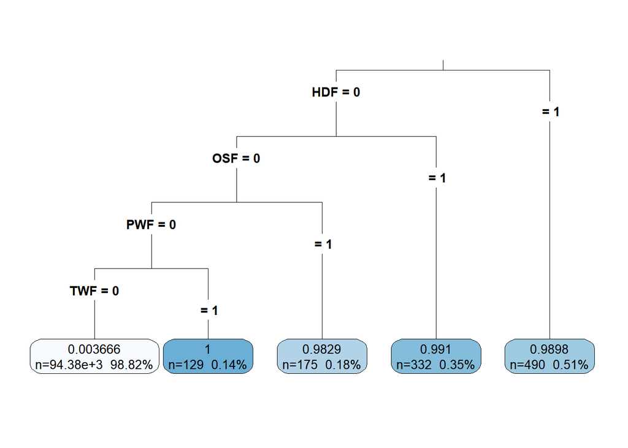

```r
##Visualizing decision trees
rpart.plot(rt_model, digits = 4, fallen.leaves = TRUE,
           type = 3, extra = 101)
```

Just like Lantz, we are going to use the **Mean Absolute Error** as way to measure model performance.

```r
###Measuring performance with mean absolute error
MAE <- function(actual, predicted) {
  mean(abs(actual - predicted))
}

MAE(rt_predict, test_data$Machine.failure)
```

```
## [1] 0.007724188
```

The result implies that **our results are, on average, 0.0077 far from the actual results** (0 and 1). Once again, this result is quite good! Finally, we can predict our solution sample.

```r
##predicting
pred_rt <- predict(rt_model, test)

solution_rt = data.frame(id = test$id, Machine.failure = round(pred_rt,0))

head(solution_rt, n=5)
```

```
##       id Machine.failure
## 1 136429               0
## 2 136430               0
## 3 136431               0
## 4 136432               0
## 5 136433               0
```

## 4.3 Decision tree

The last method we are going to use is the **decision tree**. We can say that “the model itself comprises a series of **logical decisions**, similar to a flowchart, with decision nodes that indicate a decision to be made on an attribute. These split into branches that indicate the decision’s choices. The tree is terminated by leaf nodes (also known as terminal nodes) that denote the result of following a combination of decisions”.

📌 This model is more typically used when it comes to categorical data, but we can try and adapt it to our case.

```r
train_data <- train_data %>%
  mutate(Failed = ifelse(Machine.failure == 1, "Failed", "Still Working")) %>%
  select(!Machine.failure)

test_data <- test_data %>%
  mutate(Failed = ifelse(Machine.failure == 1, "Failed", "Still Working")) %>%
  select(!Machine.failure)
```

First, we are going to add a column to our datasets that returns **Failed** and **Still Working**, based off the condition of the machine; then, we can train our model.

```r
fitControl = trainControl(method = "cv", number = 10, savePredictions = TRUE)

dt_model = train(Failed ~ ., # Set Y variable followed by '~'. The period indicates to include all variables for prediction.
                  data = train_data, # Data
                  method = 'rpart', # Specify SVM model
                  trControl = fitControl) # Use cross validation

confusionMatrix(dt_model)
```

```
## Cross-Validated (10 fold) Confusion Matrix
##
## (entries are percentual average cell counts across resamples)
##
##                Reference
## Prediction      Failed Still Working
##   Failed           0.9           0.0
##   Still Working    0.6          98.5
##
##  Accuracy (average) : 0.9937
```

We can also view the importance of our variables, as well as visual representation of our decision tree.

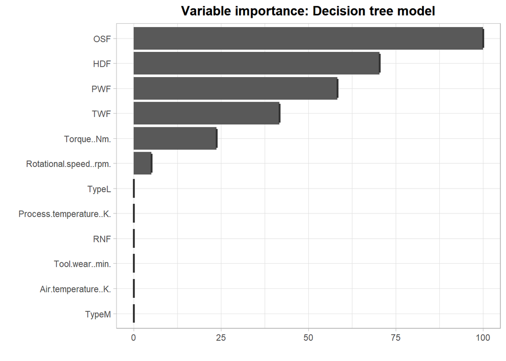

```r
### Create object of importance of our variables

dt_importance <- varImp(dt_model)

#### Create plot of importance of variables.

ggplot(data = dt_importance, mapping = aes(x = dt_importance[,1])) + # Data & mapping
  geom_boxplot() + # Create box plot
  theme_light() +
  labs(title="Variable importance: Decision tree model",
       fill="",
       x="",
       y="") +
  theme(plot.title = element_text(hjust = 0.5, face = "bold"))
```

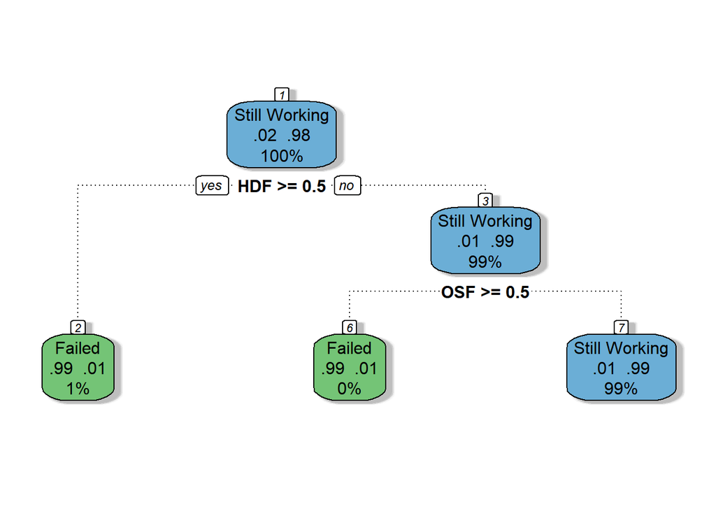

[output not shown]

```r
### Now lets plot the decision tree using fancyRpartPlot() from the RATTLE package. This will give us clear insight into how the model makes its predictions.

fancyRpartPlot(dt_model$finalModel, sub = '')
```

Finally, we can predict our model - we are going to add back the dummy column that returns 0 for machines still working and 1 otherwise.

```r
pred_dt <- predict(dt_model, test)

solution_dt = data.frame(id = test$id, Failed = pred_dt)

solution_dt <- solution_dt %>%
  mutate(Machine.Failure = ifelse(Failed == "Failed", 1,0))

head(solution_dt, n=5)
```

```
##       id        Failed Machine.Failure
## 1 136429 Still Working               0
## 2 136430 Still Working               0
## 3 136431 Still Working               0
## 4 136432 Still Working               0
## 5 136433 Still Working               0
```

# 5 Conclusion

One really nice thing to note is that the models used mainly the **categorical variables to produce the prediction** - it is quite clear when we look the decision and regression trees. This goes back to our **overall analysis**, where we first stated that **HDF, PWF and OSF** seem to be key factors on determining if a machine failed or not. It also shows how even a basic graphical/statiscal overview of the data can be helpful when it comes to **understanding patterns**. We were able to predict our answers based on **three different models**. If we explore the sample submissions, we can see that there were some differences in the values inputed, but **overall all the models returned quite similar results**.